# Effects of Loan Characteristics on BorrowerAPR/Rate

## Investigation Overview

In this investigation, I want to look at the characteristics of loans that could be used to predict their borrowerRate. The main focus was on the original loan amount, borrower's Rate, CreditGrade, loan term, Prosperscore, stated monthly income.

## Dataset Overview

The dataset consisted of borrower APRs and attributes of 113,912 loans. The attributes included the Loan Original Amount, borrower's Prosperscore, loan term, borrower's CreditGrade, as well as many other features such as borrower's Rate, current loan status etc. 25 data points were removed from the analysis due to missing borrower APR and Occupation information.

```python
# import all packages and set plots to be embedded inline
import numpy as np
import pandas as pd
import matplotlib.pyplot as plt
import seaborn as sb

%matplotlib inline

# suppress warnings from final output
import warnings
warnings.simplefilter("ignore")
```

```python
# load in the dataset into a pandas dataframe
loan = pd.read_csv("Cleaned_LoanData.csv")
```

```python
# Convert CreditGrade into ordered categorical type
grad_order=["AA","A","B","C","D","E","HR","NC"]
ordered_var = pd.api.types.CategoricalDtype(ordered = True,
                                    categories = grad_order)
loan['CreditGrade'] = loan['CreditGrade'].astype(ordered_var)
```

### Distribution of Borrower APR

The distribution of APR looks multimodal. A small peak centered at 0.1, a large peak centered at 0.2. There is also a small peak centered at 0.3. Additionally, there is a very sharp peak 0.36. Only very few loans have APR greater than 0.43.

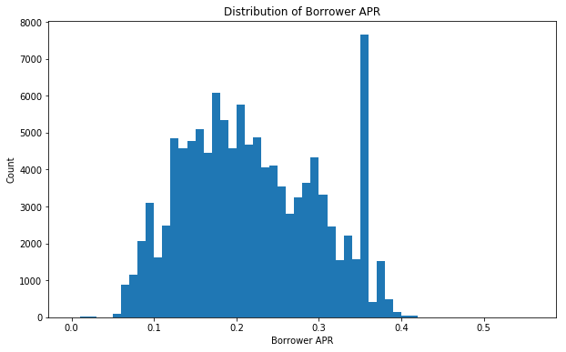

```python
bins = np.arange(0, loan.BorrowerAPR.max()+0.05, 0.01)
plt.figure(figsize=[10, 6])
plt.hist(data = loan, x = 'BorrowerAPR', bins = bins);
plt.xlabel('Borrower APR');
plt.ylabel('Count');
plt.title('Distribution of Borrower APR');
```

### Distribution of Stated Monthly Income

- The distribution of stated monthly income is severely right skewed, with stated monthly income less than 30k. and peak around 3K and 5K.
- The most common monthly income is 4166 having 3.1%, followed by 5000 having a percentage of 2.9 .
- Now let's keep only monthly income of 30000 below

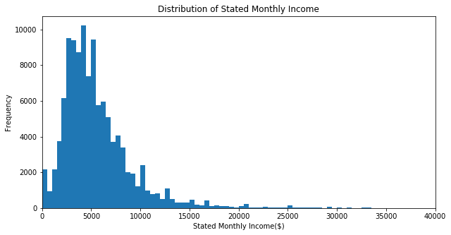

```python
# making limit in x axis
plt.figure(figsize=[10,5])
bins=np.arange(0, loan["StatedMonthlyIncome"].max()+500,500)
plt.hist(data=loan, x="StatedMonthlyIncome", bins=bins);
plt.xlim(0,40000);

#labels and title
plt.xlabel("Stated Monthly Income($)")
plt.ylabel("Frequency")
plt.title("Distribution of Stated Monthly Income");
```

### ProsperScore vs. Borrower rates

- This plot shows a strong indication that prosper score is a good determining factor of borrower's rate. We can see that the lower the interest rate, the higher the score. and vis-a-vis
- This can also indicate that borrowers with lower interest rate have a lower risk with prosper score.

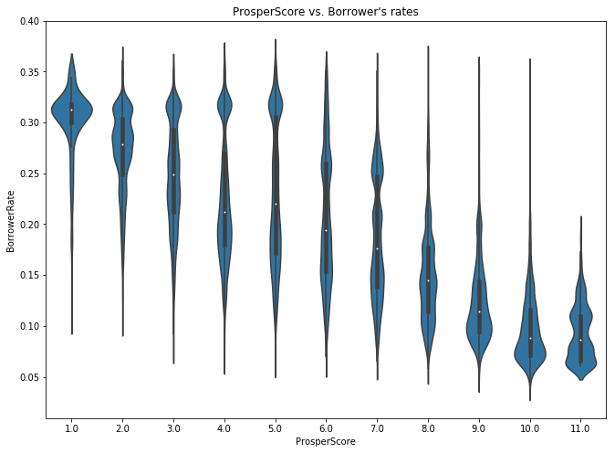

```python
# Plotting a violinplot
color = sb.color_palette()[0]
plt.figure(figsize=[11, 8]);
sb.violinplot(data = loan, x = 'ProsperScore', y = 'BorrowerRate', color = color);
plt.title('ProsperScore vs. Borrower\'s rates');
```

### LoanOriginalAmount vs ProsperScore vs BorrowerRate

- From the first figure, It shows that Loan original amount increases with an increase in Prosper score, which means there's a positive relationship.This also means that borrowers of large amount of loan tends to be at lower risk with prosper.
- The second plot shows that at different size of the loan amount, the APR has a large range, but the range of APR decreases with an increase in loan amount. Overall, the borrower APR is negatively correlated with loan amount.
- This generally indicate that people who borrows large amount of loan have lower interest rates and also have a lower risk(high score) with prosper.

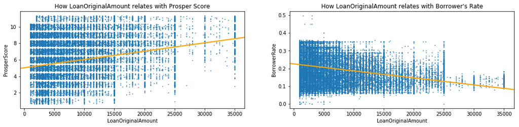

```python
plt.figure(figsize = [18, 8])

plt.subplot(2, 2, 1)
sb.regplot(data = loan, x = 'LoanOriginalAmount', y = 'ProsperScore',
                y_jitter=0.35, scatter_kws={'s':1}, line_kws={'color':'orange'});
plt.title('How LoanOriginalAmount relates with Prosper Score')

plt.subplot(2, 2, 2)
sb.regplot(data = loan, x = 'LoanOriginalAmount', y = 'BorrowerRate',
                scatter_kws={'s':1}, line_kws={'color':'orange'});
plt.title('How LoanOriginalAmount relates with Borrower\'s Rate');
```

### Effect of CreditGrade on the relationship of APR and loan amount

- The loan amount increases with better Credit Grades. The borrower APR decreases with better Grades.
- People who borrowed a large loan amount tend to have a lower borrower APR, compared to people who borrows less amount.
- Interestingly, the relationship between borrower APR and loan amount turns from negative to slightly positive when the Credit Grades are increased from HR to AA or better. This may because people with A or AA Grades tend to borrow more money.
- Increasing APR could prevent them from borrowing even more and maximize the profit. And decreasing APR for people with lower Grades who borrows less money, could encourage them to borrow more.

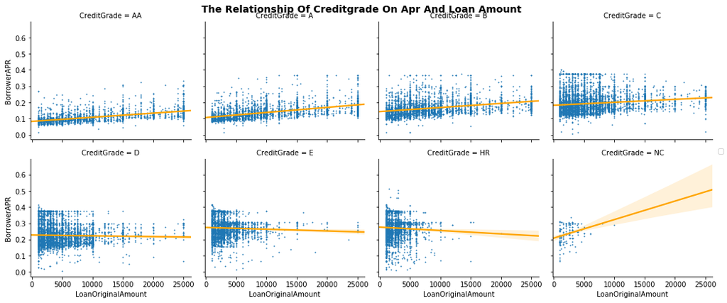

```python
# CreditGrade effect on the relationship of APR and loan amount
g=sb.FacetGrid(data=loan, aspect=1.2, col='CreditGrade', col_wrap=4)
g.map(sb.regplot, 'LoanOriginalAmount', 'BorrowerAPR', scatter_kws={'s':1}, line_kws={'color':'orange'});

# Adding main title
plt.suptitle("The Relationship of CreditGrade on APR and loan amount".title(),
              y = 1, fontsize = 14, weight = "bold")
g.add_legend();
```

### Numeric Variables Against Categorical Variables

- The plot shows that the loan amount is increased with an increase in loan term. Loan amount of borrowers also tends to increase with a better CreditGrade.Loan amount also increases with an incrrease in prosper score.
- The borrower APR decreases with the better CreditGrade. Borrowers with the best CreditGrade have the lowest APR. It means that the CreditGrade has a strong effect on borrower APR. The lower the interest rate/APR the higher the score
- Borrowers with better CreditGrade also have larger monthly income. Monthly income increases with an increase in prosper score i.e the higher the stated monthly income the higher the score.

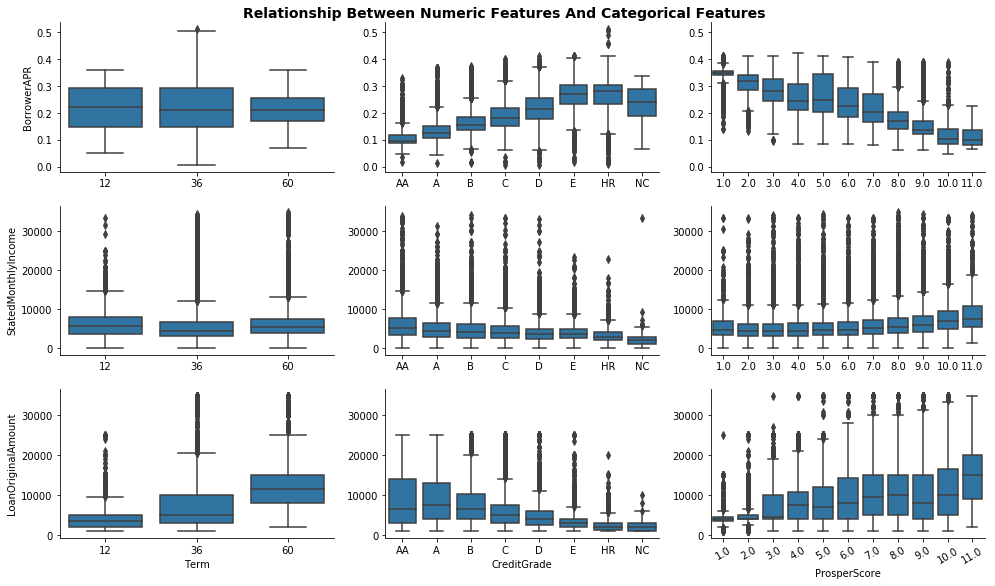

```python
# plot matrix of numeric features against categorical features.

def boxgrid(x, y, **kwargs):
    """ Quick hack for creating box plots with seaborn's PairGrid. """
    sb.boxplot(x, y, color = color)

plt.figure(figsize = [10, 10])
g = sb.PairGrid(data = loan, y_vars = ['BorrowerAPR', 'StatedMonthlyIncome', 'LoanOriginalAmount'],
                x_vars = ['Term','CreditGrade', 'ProsperScore'], aspect = 1.5)

plt.suptitle("Relationship between Numeric Features and Categorical Features".title(), y = 1,
              fontsize = 14, weight = "bold")

g.map(boxgrid);
# Set Plot Dimensions - FIGURE LEVEL
g.fig.set_size_inches(14, 8);
plt.xticks(rotation=30);
```

```python
# Use this command if you are running this file in local
!jupyter nbconvert Part_II_slide_Deck.ipynb --to slides --post serve --no-input --no-prompt
```

[output not shown]